# Analyse du dataset DataAvalancheOrg.json

## Note au sujet du dataset et de cette étude

```
Cette étude s'inscrit dans le cadre de l'UE LifProjet dispensée par l'université Lyon 1.
Ses auteurs auteurs sont Gérome FERRAND et Aymeric TOUCHE.
Vous trouverez la majeure partie des travaux sur
[le site du projet](http://lif.sci-web.net/~toufer/)
```

### Origine du jeux de données

```
Ce dataset à été scrappé sur le site (http://www.data-avalanche.org/)[http://www.data-avalanche.org/].
Il s'agit d'un site recensant une partie des avalanches de tous lieux par l'association data-avalanche.org.
Cette dernière oeuvre "pour l’amélioration et le partage de connaissances sur les avalanches".
```

### Au sujet de la présente annalyse

```
Cette page est une annalyse sommaire des données récoltées.
Cependant, nous ne sommes pas qualifiés pour prétendre que celle-ci puisse être admise comme une étude sérieuse, mais plus comme le résultat d'un bidouillage amusant. :)
```

### Avertissement

[output not shown]

## Annalyse

```python
# Import des bibliothèques utiles
import numpy as np
import pandas as pd
import json
import matplotlib.pyplot as plt
import seaborn as sns

# import des données
tab_raw_avalanche = pd.read_json(r'DataAvalancheOrg.json')

# option
pd.set_option('display.max_rows', None) # permet de visualiser l'intégralité des données affichées
```

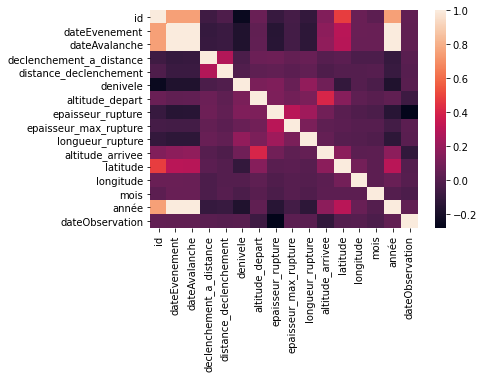

```python
sns.heatmap(tab_raw_avalanche.corr())
```

Sur un malentendu, nous aurions pu apercevoir quelques correlations entre les différentes composantes du jeu de donnée !

### Statistiques rapides

```
orientation
NE    256
N     300
NW    279
W     242
SW    127
S     150
SE    189
E     197
dtype: int64
```

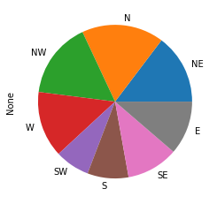

```python
# répartition par orientation des avalanches

tab_orientation = tab_raw_avalanche.iloc[:,[6]]
tab_orientation = tab_orientation[tab_orientation['orientation'] != 'T']

repartition_orientation = tab_orientation.groupby('orientation').size()
repartition_orientation = repartition_orientation.reindex(['NE', 'N', 'NW', 'W', 'SW', 'S', 'SE', 'E'])

repartition_orientation.plot(kind='pie')

repartition_orientation
```

On remarque que près de la moitié des avalanches sont marquées face nord. Ici, rien de bien transcendant...

```
origine_principale
Skieur rando.  descente    273
Skieur hors piste          268
Réchauffement              245
Neige                      174
Skieur rando.  montée      169
dtype: int64
```

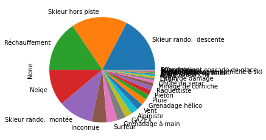

```python
# Répartition par activités ayant déclenchées les avalanches

tab_declenchement = tab_raw_avalanche.iloc[:,[16]]
tab_declenchement = tab_declenchement[tab_declenchement['origine_principale'] != '']
tab_declenchement = tab_declenchement.groupby('origine_principale').size().sort_values(ascending = False)

tab_declenchement.plot(kind = 'pie')

print(tab_declenchement.head())
```

On peut noter que les avalanches sont fréquemment déclenchées par les skieurs, le réchauffement ou encore les chutes de neige.

```
caracteristique
Plaque de fond        197
Plaque à vent         192
Plaque friable        164
Départ ponctuel        28
Plaque dure            12
Plaque sur glacier     11
Sur-avalanche           5
Tir négatif             2
dtype: int64
```

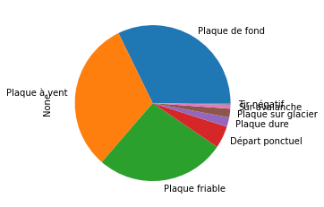

```python
# répartition par caractéristiques

tab_carac = tab_raw_avalanche.iloc[:,[14]]
tab_carac = tab_carac[tab_carac['caracteristique'] != '']
repartition_carac = tab_carac.groupby('caracteristique').size().sort_values(ascending = False)

repartition_carac.plot(kind='pie')

repartition_carac
```

Bien que la plupart des données n'ait pas de caractéristique renseignée, nous pouvons tout de même voir les principales plaques, uniformément reparties.

```
massif
Haute Maurienne     275
Vanoise             217
Haute Tarentaise    147
Maurienne           116
Mont Thabor         102
dtype: int64
```

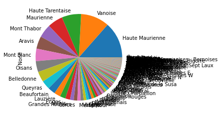

```python
# Répartition par massif

tab_massif = tab_raw_avalanche.iloc[:,[3]]
# tab_massif = tab_massif[tab_carac['massif'] != '']
repartition_massif = tab_massif.groupby('massif').size().sort_values(ascending = False)

repartition_massif.plot(kind='pie')

repartition_massif.head()
```

Il semblerait que l'association ayant recensée ces données se situe à Aussois, en pleine haute-Maurienne. Ce diagramme semble davantage nous indiquer les régions les plus visitées par les itinérants de l'asso. que les régions plus touchées par les avalanches.

### Répartition temporelle

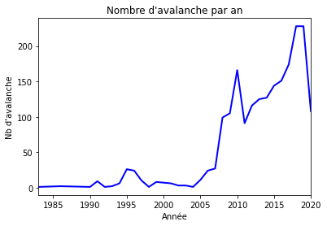

```python
# Etude du nombre d'avalanche par an

nb_ava_par_an = pd.Series(tab_raw_avalanche.groupby('année').size().sort_index(axis = 0))
x = nb_ava_par_an.index
y = nb_ava_par_an.values

fig = plt.figure()
ax = fig.add_subplot()
ax.plot(x, y, color = 'blue', linewidth = 2)
ax.set_xlim(1983, 2020)

plt.title("Nombre d'avalanche par an")
plt.xlabel("Année")
plt.ylabel("Nb d'avalanche")
plt.show()
```

```python
# on peut estimer que le nombre d'avalanche devient significatif à partir de 90 (arbitraire, ou presque)

nb_ava_par_an_90plus = nb_ava_par_an[nb_ava_par_an.between(90,9999)]
annee_seuil_90plus = nb_ava_par_an_90plus.index[0] # out : 2008

print("Année à partir de laquelle le taux d'avalanche est supérieur à 90 :")
print(annee_seuil_90plus)
```

```
Année à partir de laquelle le taux d'avalanche est supérieur à 90 :
2008
```

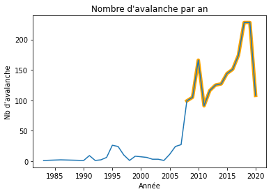

```python
# Partie des valeurs supérieures à 90 avalanches
x = nb_ava_par_an_90plus.index
y = nb_ava_par_an_90plus.values

fig_nb = plt.figure()

ax = fig_nb.add_subplot()
ax.plot(x, y, color = 'orange', linewidth = 5)
nb_ava_par_an.plot()

plt.title("Nombre d'avalanche par an")
plt.xlabel("Année")
plt.ylabel("Nb d'avalanche")
plt.show()
```

```
De 2008 à 2019 = 1754 lignes au total.

Au total :
mois
1     296
2     334
3     364
4     240
5     109
6      15
7       3
8       3
9       4
10      6
11     73
12    307
dtype: int64
```

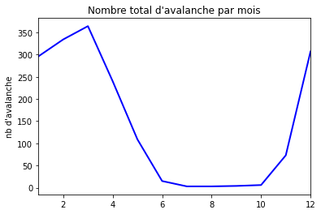

```python
# récupération des avalanches après 2008
tab_avalanche_post_2008 = tab_raw_avalanche[tab_raw_avalanche['année'].between(annee_seuil, 9999)]
# retrait de l'année 2020 car elle n'est pas terminée et elle biaisera les valeurs
tab_avalanche_2008_to_2019 = tab_avalanche_post_2008[tab_avalanche_post_2008['année'] != 2020]

print("De 2008 à 2019 = " + str(len(tab_avalanche_2008_to_2019)) + " lignes au total.\n")

nb_ava_mois = tab_avalanche_2008_to_2019.groupby('mois').size().sort_index(axis = 0)
print("Au total :")
print(nb_ava_mois)

x = nb_ava_mois.index
y = nb_ava_mois.values

fig = plt.figure()
ax = fig.add_subplot(111)
ax.plot(x, y, color = 'blue', linewidth = 2)
ax.set(xlim = [1,12])

plt.title("Nombre total d'avalanche par mois")
plt.ylabel("nb d'avalanche")
plt.show()
```

```python
# Répartition du nombre d'avalanches par an par mois

# Retrait des données de 2020
nb_ava_par_an_2008_to_2019 = nb_ava_par_an_90plus[nb_ava_par_an_90plus.index != 2020]

# création du dataframe de reception des données
tab_nb_ava_an_par_mois = pd.DataFrame(index = nb_ava_mois.index, columns = nb_ava_par_an_2008_to_2019.index)

# remplissage du dataframe
for a in nb_ava_par_an_2008_to_2019.index :
    tab = tab_avalanche_2008_to_2019[tab_avalanche_2008_to_2019['année'] == a].groupby('mois').size().sort_index(axis = 0)

    x = tab.index
    y = tab.values

    tab_nb_ava_an_par_mois[a] = pd.Series(y, index = x)

tab_nb_ava_an_par_mois
```

| année mois | 2008 | 2009 | 2010 | 2011 | 2012 | 2013 | 2014 | 2015 | 2016 | 2017 | 2018 | 2019 |
| --- | --- | --- | --- | --- | --- | --- | --- | --- | --- | --- | --- | --- |
| 1 | 11.0 | 24.0 | 33.0 | 10.0 | 19.0 | 18.0 | 33.0 | 36.0 | 36.0 | 15.0 | 31.0 | 30.0 |
| 2 | 9.0 | 19.0 | 39.0 | 15.0 | 24.0 | 14.0 | 29.0 | 41.0 | 20.0 | 37.0 | 38.0 | 49.0 |
| 3 | 15.0 | 16.0 | 28.0 | 40.0 | 13.0 | 32.0 | 20.0 | 30.0 | 22.0 | 59.0 | 71.0 | 18.0 |
| 4 | 16.0 | 14.0 | 23.0 | 12.0 | 16.0 | 31.0 | 9.0 | 19.0 | 28.0 | 7.0 | 40.0 | 25.0 |
| 5 | 9.0 | 3.0 | 7.0 | 2.0 | 16.0 | 4.0 | 8.0 | 13.0 | 11.0 | 10.0 | 2.0 | 24.0 |
| 6 | 2.0 | NaN | NaN | NaN | 1.0 | 5.0 | NaN | NaN | 3.0 | NaN | 1.0 | 3.0 |
| 7 | NaN | NaN | NaN | NaN | 1.0 | NaN | NaN | NaN | 2.0 | NaN | NaN | NaN |
| 8 | 1.0 | 1.0 | NaN | NaN | NaN | 1.0 | NaN | NaN | NaN | NaN | NaN | NaN |
| 9 | 1.0 | NaN | 1.0 | NaN | 1.0 | NaN | NaN | 1.0 | NaN | NaN | NaN | NaN |
| 10 | 1.0 | 1.0 | NaN | NaN | NaN | 2.0 | NaN | NaN | 2.0 | NaN | NaN | NaN |
| 11 | 6.0 | NaN | 12.0 | 2.0 | 2.0 | 1.0 | 2.0 | 2.0 | 16.0 | NaN | 14.0 | 16.0 |
| 12 | 28.0 | 27.0 | 23.0 | 10.0 | 23.0 | 17.0 | 26.0 | 2.0 | 11.0 | 46.0 | 31.0 | 63.0 |

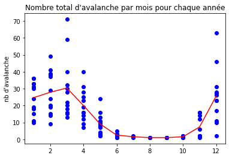

```python
# Moyenne du nombre d'avalanche par mois
fig = plt.figure()

# affichage de l'échantillon de chaque année
for a in tab_nb_ava_an_par_mois :
    serie_annee = tab_nb_ava_an_par_mois[a]
    x = serie_annee.index
    y = serie_annee.values

    ax = fig.add_subplot()
    ax.scatter(x, y, color = 'blue')

# affichage de la moyenne
x = tab_nb_ava_an_par_mois.mean(axis = 1).index
y = tab_nb_ava_an_par_mois.mean(axis = 1).values

ax = fig.add_subplot()
ax.plot(x, y, color = 'red')


plt.title("Nombre total d'avalanche par mois pour chaque année")
plt.ylabel("nb d'avalanche")
plt.show()

# graphique pas très exact car non relatif au nombre de données par an
```

```python
# répartition des avalanches sur l'année (en %)
tab_repartition_ava_over_year = tab_nb_ava_an_par_mois.copy()

for a in tab_nb_ava_an_par_mois :
    for m in tab_nb_ava_an_par_mois[a].index :
        tab_repartition_ava_over_year[a][m] = round((tab_nb_ava_an_par_mois[a][m])/(tab_nb_ava_an_par_mois[a].sum()),2)

tab_repartition_ava_over_year
```

| année mois | 2008 | 2009 | 2010 | 2011 | 2012 | 2013 | 2014 | 2015 | 2016 | 2017 | 2018 | 2019 |
| --- | --- | --- | --- | --- | --- | --- | --- | --- | --- | --- | --- | --- |
| 1 | 0.11 | 0.23 | 0.20 | 0.11 | 0.16 | 0.14 | 0.26 | 0.25 | 0.24 | 0.09 | 0.14 | 0.13 |
| 2 | 0.09 | 0.18 | 0.23 | 0.16 | 0.21 | 0.11 | 0.23 | 0.28 | 0.13 | 0.21 | 0.17 | 0.21 |
| 3 | 0.15 | 0.15 | 0.17 | 0.44 | 0.11 | 0.26 | 0.16 | 0.21 | 0.15 | 0.34 | 0.31 | 0.08 |
| 4 | 0.16 | 0.13 | 0.14 | 0.13 | 0.14 | 0.25 | 0.07 | 0.13 | 0.19 | 0.04 | 0.18 | 0.11 |
| 5 | 0.09 | 0.03 | 0.04 | 0.02 | 0.14 | 0.03 | 0.06 | 0.09 | 0.07 | 0.06 | 0.01 | 0.11 |
| 6 | 0.02 | NaN | NaN | NaN | 0.01 | 0.04 | NaN | NaN | 0.02 | NaN | 0.00 | 0.01 |
| 7 | NaN | NaN | NaN | NaN | 0.01 | NaN | NaN | NaN | 0.01 | NaN | NaN | NaN |
| 8 | 0.01 | 0.01 | NaN | NaN | NaN | 0.01 | NaN | NaN | NaN | NaN | NaN | NaN |
| 9 | 0.01 | NaN | 0.01 | NaN | 0.01 | NaN | NaN | 0.01 | NaN | NaN | NaN | NaN |
| 10 | 0.01 | 0.01 | NaN | NaN | NaN | 0.02 | NaN | NaN | 0.01 | NaN | NaN | NaN |
| 11 | 0.06 | NaN | 0.07 | 0.02 | 0.02 | 0.01 | 0.02 | 0.01 | 0.11 | NaN | 0.06 | 0.07 |
| 12 | 0.28 | 0.26 | 0.14 | 0.11 | 0.20 | 0.14 | 0.20 | 0.01 | 0.07 | 0.26 | 0.14 | 0.28 |

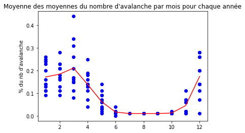

```python
# Moyenne des moyennes du nombre d'avalanche par mois
fig = plt.figure()

# affichage de l'échantillon de chaque année
for a in tab_repartition_ava_over_year :
    serie_annee = tab_repartition_ava_over_year[a]
    x = serie_annee.index
    y = serie_annee.values

    ax = fig.add_subplot()
    ax.scatter(x, y, color = 'blue')

# affichage de la moyenne
x = tab_repartition_ava_over_year.mean(axis = 1).index
y = tab_repartition_ava_over_year.mean(axis = 1).values

ax = fig.add_subplot()
ax.plot(x, y, color = 'red')


plt.title("Moyenne des moyennes du nombre d'avalanche par mois pour chaque année")
plt.ylabel("% du nb d'avalanche")
plt.show()

# il semblearait qu'en réalité on se retrouve sur une courbe très similaire...
# si ce n'est normalisé
```

### Correlation entre le type de plaque et l'orientation de l'avalanche

#### note sur les types d'avalanches et de plaques :

**avalanches à départ ponctuel :**

> Ces avalanches concernent des neiges avec peu ou pas de cohésion : poudreuse froide type faces planes, ou neige de fonte gorgée d'eau. Elles sont un peu moins dangereuses du fait des plus faibles quantités de neige mobilisées, et risquent moins d'emporter le pratiquant qui les déclenche car elles partent en dessous de lui. (wikipedia)

```
ce sont donc des avalanches qui adoptent une forme de poires, ou encore de goutte. on pourrait les opposer au avalanches en plaques.
```

**avalanches en plaques :**

```
En opposition aux plaques à départ ponctuel,
```

> Ces avalanches sont caractérisées dans leur zone de départ par une fracture linéaire du manteau neigeux, rupture en profondeur visible fréquemment en ligne brisée, qui génère ainsi la mise en mouvement d'une plaque de neige. Celle-ci peut être constituée de neige dure (cohésive) ou friable (poudreuse, parfois très légère). Ces avalanches impliquent très fréquemment une couche fragile sous-jacente de neige à faible cohésion, le plus souvent du givre de profondeur ou plus rarement du givre de surface enfoui, mais aussi parfois des plaques à vent dont le rôle peut toutefois être surestimé. Le départ de ces avalanches peut facilement s'étendre quasi instantanément sur une superficie importante, et mobiliser alors de très grandes quantités de neige, dans des zones parfois éloignées de la rupture initiale.  
> Ces avalanches dites de plaque sont assez facilement déclenchées par des skieurs ou par des randonneurs et ce sont celles qui font le plus de victimes. Si parfois on peut être alerté par des bruits de soufflement ou d'effondrement quand on évolue dessus, il est généralement très difficile de les reconnaître a priori." (wikipedia)

**Plaques à vent :**

> La plaque à vent est une étendue de neige amassée en cohésion par le vent dans une zone abritée au-delà d'une rupture de pente ou au voisinage d'une crête.(wikipedia)

**Plaques de fond :**

```
Comme leur nom l'indique, ces avalanches emportent le manteau neigeux sur toute son épaisseur, jusqu'au sol (jusqu'au fond du manteau).
```

**Plaques dure et friable:** On oppose les avalanches à plaques dures à celle à plaques friable.

> Les avalanches de plaques dures, constituées d'une neige assez lourde et de bonne cohésion, mais qui s'étend sur une sous-couche fragile. Elles détachent des plaques dures, parfois formées par l'action du vent sur les cristaux de neige, et les zones qu'elles recouvrent sont parsemées de blocs tabulaires.(météo-france)

```python
# Création d'un dataframe avec les lignes dont l'orientation et le type de plaques sont renseignés
# hsitogramme en barres par orientation recensant les type de plaques

#extraction des données a partir du dataframe originel
tab_orien_carac = tab_raw_avalanche.iloc[:,[6,14,]]
tab_orien_carac = tab_orien_carac[tab_orien_carac['orientation'] != 'T']
tab_orien_carac = tab_orien_carac[tab_orien_carac['caracteristique'] != '']
tab_orien_carac = tab_orien_carac[tab_orien_carac['caracteristique'] != 'Tir négatif']
tab_orien_carac = tab_orien_carac[tab_orien_carac['caracteristique'] != 'Sur-avalanche']

print("nombre de lignes ayant 'orientation' et 'caractéristique' renseignés : " + str(len(tab_orien_carac)))
print('hors : tir-négatif et sur-avalanche\n')
```

```
nombre de lignes ayant 'orientation' et 'caractéristique' renseignés : 575
hors : tir-négatif et sur-avalanche
```

```python
#apercu de la répartition du nb de lignes par orientation
nb_ligne_par_orient = tab_orien_carac.groupby('orientation').size().sort_index(axis = 0)
nb_ligne_par_orient = nb_ligne_par_orient.reindex(['NE', 'N', 'NW', 'W', 'SW', 'S', 'SE', 'E'])
nb_ligne_par_orient = nb_ligne_par_orient.to_frame()
nb_ligne_par_orient.columns = ['nb']
nb_ligne_par_orient
```

| orientation | nb |
| --- | --- |
| NE | 75 |
| N | 71 |
| NW | 82 |
| W | 77 |
| SW | 40 |
| S | 64 |
| SE | 95 |
| E | 71 |

```python
#apercu de la répartition du nb de lignes par plaque
nb_ligne_par_plaque = tab_orien_carac.groupby('caracteristique').size().sort_index(axis = 0)
nb_ligne_par_plaque = nb_ligne_par_plaque.to_frame()
nb_ligne_par_plaque.columns = ['nb']
nb_ligne_par_plaque
```

| caracteristique | nb |
| --- | --- |
| Départ ponctuel | 27 |
| Plaque de fond | 189 |
| Plaque dure | 12 |
| Plaque friable | 156 |
| Plaque sur glacier | 11 |
| Plaque à vent | 180 |

```python
#Création du dataframe de repartition des types de plaques par orientation
repartition_plaques_par_orient = pd.DataFrame(index = nb_ligne_par_orient.index, columns = nb_ligne_par_plaque.index)

#Remplissage du dataframe
for o in nb_ligne_par_orient.index :
    repartition_plaques_par_orient.loc[o] = tab_orien_carac[tab_orien_carac['orientation'] == o].groupby('caracteristique').size()

repartition_plaques_par_orient
```

| caracteristique orientation | Départ ponctuel | Plaque de fond | Plaque dure | Plaque friable | Plaque sur glacier | Plaque à vent |
| --- | --- | --- | --- | --- | --- | --- |
| NE | 2 | 17 | 3 | 28 | 1 | 24 |
| N | 7 | 3 | 2 | 32 | 5 | 22 |
| NW | 3 | 10 | 4 | 35 | 2 | 28 |
| W | 4 | 24 | 2 | 16 | 1 | 30 |
| SW | 2 | 17 | NaN | 9 | 1 | 11 |
| S | 5 | 30 | NaN | 11 | NaN | 18 |
| SE | 1 | 56 | 1 | 9 | 1 | 27 |
| E | 3 | 32 | NaN | 16 | NaN | 20 |

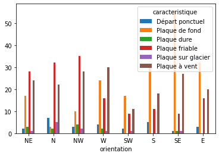

```python
ax = repartition_plaques_par_orient.plot.bar(rot = 0)
```

Il semblerait ici que les plaques à vent soient uniformément répartis.

Les plaques de fond sont légèrement plus représentées sur les faces sud.

Les plaques friables sont quant à elles plus présentes sur les faces Nord.